# GTD Group Project

datING - BDA 503 - Fall 2017

07 December 2017

## Group Name

- **datING**

## Group Members

1. [Bilge Uzuner](https://mef-bda503.github.io/pj-uzunerb/)
2. [Sefa Erbas](https://mef-bda503.github.io/pj-erbass/)
3. [Türkan Sevgili](https://mef-bda503.github.io/pj-sevgilit/)

## Data

- Global Terrorism Data

### Description

The Global Terrorism Database ([GTD](http://start.umd.edu/gtd/about/)) includes information on terrorist events around the World (205 countries, more than 33000 cities, from 1970 through 2016 on at least 45 variables for each case, with more recent incidents including information on more than 120 variables

### Content and Data fields

*Geography:* Worldwide

*Time period:* 1970-2016, except 1993

*Unit of analysis:* Attack

*Variables:* >100 variables on location, tactics, perpetrators, targets, and outcomes

*Sources:* Unclassified media articles

Necessary information about mostly used fields can be found below. You can see the [GTD Codebook](http://start.umd.edu/gtd/downloads/Codebook.pdf) for broadly explained definitons on fields, important details on data collection methodology, definitions, and coding schema.

- `eventid:` Incidents from the GTD follow a 12-digit Event ID system.
- `iyear:` This field contains the year in which the incident occurred.
- `imonth:` This field contains the number of the month in which the incident occurred.
- `iday:` This field contains the numeric day of the month on which the incident occurred.
- `country:` This field identifies the country code country or location where the incident occurred.
- `region:` This field identifies the region code in which the incident occurred.
- `provstate:` This variable records the name (at the time of event) of the 1st order subnational administrative region in which the event occurs.
- `city:` This field contains the name of the city, village, or town in which the incident occurred.
- `latitude:` This field records the latitude (based on WGS1984 standards) of the city in which the event occurred.
- `longitude:` This field records the longitude (based on WGS1984 standards) of the city in which the event occurred.
- `location:` This field is used to specify additional information about the location of the incident.
- `success:` Success of a terrorist strike is defined according to the tangible effects of the attack. Success is not judged in terms of the larger goals of the perpetrators.

## Objectives

- The purpose of the analysis is to understand the Turkey’s Terorism Statistics on the basis of the cities, districts, dates, seasons etc.
- Try to define the factors that influence the terror attacks in Turkey.
- A clear understanding of the data to see if we can locate useful insights about where and when terror attacks occur in Turkey.
- To create an opinion on the relatively risky and secure regions based on past experience, by in-depth analysis of the terrorist attacks in Turkey, also to see relatively safe and risky periods during the year.

## Abstract

*Definition of terrorism:* “The threatened or actual use of illegal force and violence by a non-state actor to attain a political, economic, religious, or social goal through fear, coercion, or intimidation.”

Terrorism is the largest human-oriented criminal organization that has become a common problem globally. Nowadays, it is known that the underlying reason of most of today’s terrorist activities is strategic actions and international purposes. Terrorist attacks in a country can take place because of interior reasons (economic prosperity, socio-cultural, educational system) or other factors. The most important of factor is the geopolitical position of the country.

## Exploratory Analysis

- Load necessary frequently used R Packages and see whole GTD dataset.

```r
# Necessary packages to load in
library(tidyverse)
library(ggplot2) # Data visualization
library(readr) # Read_csv function
library(dplyr)
options(dplyr.width=Inf)
#Sys.setlocale(locale = "Turkish_Turkey.1254")
```

```r
# Get all data

gtd = read.csv(file="https://bitbucket.org/sevgilit/bda503/raw/8ef59a06fd743de89955610b2af9ca4e288bc1c1/globalterrorismdb_0617dist.csv", header=TRUE, sep=",")

# subset gtd data to attacks in Turkey
turkey.gtd <- gtd%>%
  filter(country_txt == "Turkey")

#if any problem
problems(turkey.gtd)

# Summary of turkey.gtd structure
glimpse(turkey.gtd)
```

### Data Cleaning

Since there are more than 100 variables, first we selected which variables are meaningful for the analysis for Turkey. Other columns are the sub categories of these informations and not available for all events.

```r
# Select columns that will use in EDA and renaming selected columns
gtd.turkey = select (turkey.gtd , eventid, year = iyear, month = imonth, day=iday, country_code = country,
                     country_name=country_txt,region_code=region, region_name=region_txt, provstate,city,
                     latitude,longitude,location,success, attacktype1=attacktype1_txt,
                     attacktype2=attacktype2_txt,attacktype3=attacktype3_txt,targtype1=targtype1_txt,
                     targsubtype1=targsubtype1_txt,weaptype1=weaptype1_txt, weapsubtype1=weapsubtype1_txt,
                     property,propextent_txt,propvalue,gname,nkill,nwound)

# Summary of gtd.turkey structure
glimpse(gtd.turkey)
```

```
## Observations: 4,106
## Variables: 27
## $ eventid        <dbl> 197004250001, 197008310001, 197010020002, 19701...
## $ year           <int> 1970, 1970, 1970, 1970, 1970, 1970, 1970, 1970,...
## $ month          <int> 4, 8, 10, 10, 10, 10, 10, 11, 11, 11, 12, 12, 1...
## $ day            <int> 25, 31, 2, 3, 3, 6, 27, 10, 21, 23, 24, 29, 7, ...
## $ country_code   <int> 209, 209, 209, 209, 209, 209, 209, 209, 209, 20...
## $ country_name   <fctr> Turkey, Turkey, Turkey, Turkey, Turkey, Turkey...
## $ region_code    <int> 10, 10, 10, 10, 10, 10, 10, 10, 10, 10, 10, 10,...
## $ region_name    <fctr> Middle East & North Africa, Middle East & Nort...
## $ provstate      <fctr> Istanbul, Ankara, Izmir, Ankara, Ankara, Ankar...
## $ city           <fctr> Istanbul, Ankara, Izmir, Ankara, Ankara, Ankar...
## $ latitude       <dbl> 41.01484, 39.91839, 38.42371, 39.91839, 39.9183...
## $ longitude      <dbl> 28.96141, 32.86560, 27.13421, 32.86560, 32.8656...
## $ location       <fctr> , , , , , , , , , , , , , , , , , , , , , , , ,
## $ success        <int> 1, 1, 1, 1, 1, 0, 1, 1, 1, 1, 0, 0, 1, 1, 0, 1,...
## $ attacktype1    <fctr> Bombing/Explosion, Bombing/Explosion, Bombing/...
## $ attacktype2    <fctr> , , , , , , , , , , , , , , , , , , , , , , , ,
## $ attacktype3    <fctr> , , , , , , , , , , , , , , , , , , , , , , , ,
## $ targtype1      <fctr> Airports & Aircraft, Military, Military, Gover...
## $ targsubtype1   <fctr> Airline Officer/Personnel, Military Unit/Patro...
## $ weaptype1      <fctr> Explosives/Bombs/Dynamite, Explosives/Bombs/Dy...
## $ weapsubtype1   <fctr> Unknown Explosive Type, Unknown Explosive Type...
## $ property       <int> 1, 1, 1, 1, 1, 1, 1, 1, 1, 1, 1, 0, 1, 1, 0, 1,...
## $ propextent_txt <fctr> , , , , , , , , , Minor (likely < $1 million),...
## $ propvalue      <dbl> NA, NA, NA, NA, NA, NA, NA, NA, NA, 25000, NA, ...
## $ gname          <fctr> Palestinians, Turkish People's Liberation Army...
## $ nkill          <int> 0, 0, 0, NA, 0, 0, 0, 0, 0, NA, 0, 0, 0, NA, 0,...
## $ nwound         <int> 0, 0, 0, NA, 0, 0, 0, 0, 0, NA, 0, 1, 0, NA, 0,...
```

The data set that will used in this project and initial exploratory data analysis on it consists of 4,106 observations and 27 variables.

Secondly we checked the data for the missing/ NA or unmeaningful data;

- - Event id is unique
- - 30/31 February is not available
- - No day 31 is available for the months 2,4,6,9,11

Country code and Region Code is unique for Turkey and Middle East & North Africa which are 209 and 10 approximately.

In the “City” column we see the district information for some of the data so we made the city analysis on “Provstate” column which we found more covenient.

- Initial exploratory analysis of GTD dataset and Turkey terrorism statistics can be found below.

It is firstly examined how many terrorist attacks have been recorded in the years since the Global Terrorist Database. (1970-2016)

#### Terrorist Attacks, 1970-2016 (Global vs Turkey)

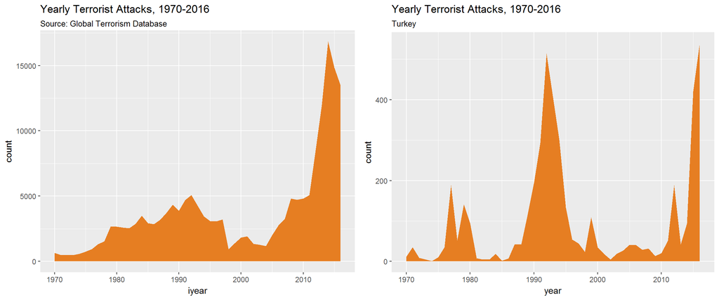

```r
library(ggplot2)
library(gridExtra)
plot1<-ggplot(data=gtd) +
  geom_area(mapping=aes(x=iyear), stat="count", fill= ('#e67e22')) +
  ggtitle("Yearly Terrorist Attacks, 1970-2016", subtitle = "Source: Global Terrorism Database")

plot2<-ggplot(data=gtd.turkey) +
  geom_area(mapping=aes(x=year), stat="count", fill= ('#e67e22')) +
  ggtitle("Yearly Terrorist Attacks, 1970-2016", subtitle = "Turkey")

grid.arrange(plot1,
             plot2,
             ncol=2)
```

In global side, there is a steady increase over time until the early ’90s, after which there is a steady decline until the mid 2000s. It is a dramatic increase (and record yearly high, in 2014) in reported attacks.

In Turkey, the upward trend observed at the beginning of the 90s declined along with the 2000s It is observed that after 2010, it has entered a new upward trend.

#### Histogram of Attacks by Year

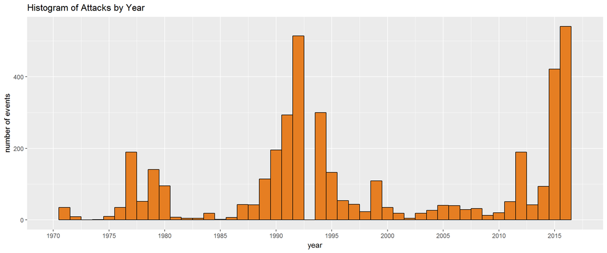

```r
library(ggplot2)
ggplot(gtd.turkey, aes(gtd.turkey$year)) +
  geom_histogram(fill= ('#e67e22'), color='black', binwidth=1) +
  scale_x_continuous(limit=c(1970, 2017), breaks=seq(1970, 2017, by = 5)) +
  labs(x= 'year', y= 'number of events') +
  ggtitle('Histogram of Attacks by Year')
```

As shown above figure,the data for year 1993 is missing in the source data.

#### Histogram of Attacks by Month

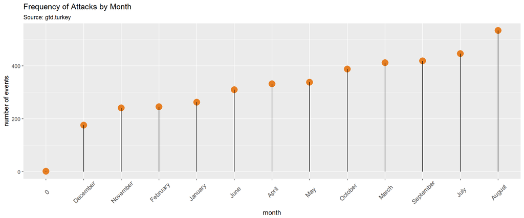

```r
# Data Preparation
gtd.turkey.month<-gtd.turkey%>%
  group_by(month)%>%
  summarise(numberOfEvents=n())

gtd.turkey.month$month[gtd.turkey.month$month == 0] <- 0
gtd.turkey.month$month[gtd.turkey.month$month == 1] <- "January"
gtd.turkey.month$month[gtd.turkey.month$month == 2] <- "February"
gtd.turkey.month$month[gtd.turkey.month$month == 3] <- "March"
gtd.turkey.month$month[gtd.turkey.month$month == 4] <- "April"
gtd.turkey.month$month[gtd.turkey.month$month == 5] <- "May"
gtd.turkey.month$month[gtd.turkey.month$month == 6] <- "June"
gtd.turkey.month$month[gtd.turkey.month$month == 7] <- "July"
gtd.turkey.month$month[gtd.turkey.month$month == 8] <- "August"
gtd.turkey.month$month[gtd.turkey.month$month == 9] <- "September"
gtd.turkey.month$month[gtd.turkey.month$month == 10] <- "October"
gtd.turkey.month$month[gtd.turkey.month$month == 11] <- "November"
gtd.turkey.month$month[gtd.turkey.month$month == 12] <- "December"

gtd.turkey.month <- gtd.turkey.month[order(gtd.turkey.month$numberOfEvents), ]
gtd.turkey.month$month <- factor(gtd.turkey.month$month, levels = gtd.turkey.month$month)

# Plot
ggplot(gtd.turkey.month, aes(x=month, y=numberOfEvents)) +
  geom_point(size=5,color='#e67e22') +
  geom_segment(aes(x=month,
                   xend=month,
                   y=0,
                   yend=numberOfEvents)) +
  labs(x= 'month', y= 'number of events') +
  labs(title="Frequency of Attacks by Month",
       subtitle="Source: gtd.turkey") +
  theme(axis.text.x = element_text(angle=45, vjust=0.6, size=10))
```

When Turkey is busy with foreign visitors and the tourism season peaks, it is seen that the terorist attacks also rise in summer months.

#### Frequency of Attacks by City

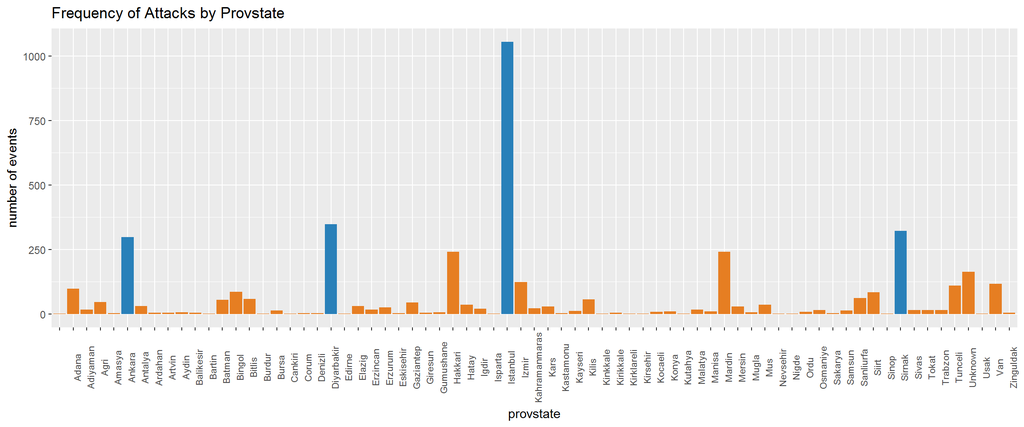

```r
gtd.turkey %>%
    group_by(provstate)%>%
    count() %>% # count the number of times a provstate appear
      ggplot(aes(x=provstate,y=n))+
      geom_bar(stat = "identity",aes(fill=n>250)) +
      theme(axis.text.x = element_text(angle=90,size=8,vjust=1, hjust=0.5)) +
      labs(x= 'provstate', y= 'number of events') +
      ggtitle('Frequency of Attacks by Provstate')+
      scale_fill_manual(values = c('#e67e22', '#2980b9'),guide=FALSE)
```

When you look at the cities most subject to terrorist attacks; Istanbul, Ankara, Diyarbakir and Sirnak attrack a great deal of attention.

Istanbul; which is a metropolis of Turkey and draws attention with its crowded population become the target of more than 1,000 terrorist attacks. While some cities face with less terrorist attacks and can be considered relatively safe (Amasya, Bartin, Burdur, Çankiri, Edirne, Isparta, Kirklareli, Kirsehir, etc.)at the same period.

Where are the places that has been attacked > 50 in Turkey between 1970 - 2016?

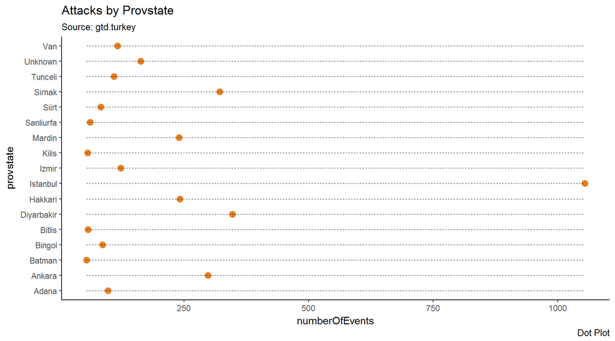

```r
library(scales)
theme_set(theme_classic())

gtd.turkey.provstate_50<-gtd.turkey%>%
  group_by(provstate)%>%
  summarise(numberOfEvents=n())%>%
  filter(numberOfEvents>50)

# Plot
ggplot(gtd.turkey.provstate_50, aes(x=provstate, y=numberOfEvents)) +
  geom_point(col='#e67e22', size=3) +   # Draw points
  geom_segment(aes(x=provstate,
                   xend=provstate,
                   y=min(numberOfEvents),
                   yend=max(numberOfEvents)),
               linetype="dashed",
               size=0.1) +   # Draw dashed lines
  labs(title="Attacks by Provstate",
       subtitle="Source: gtd.turkey",
       caption="Dot Plot") +
  coord_flip()
```

#### Success/Failure Rates

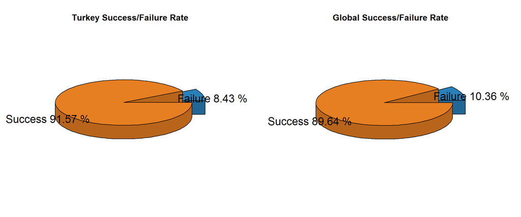

```r
library(plotrix)
library(ggplot2)
par(mfrow = c(1,2))

#Percentages Global&Turkey
a<-gtd.turkey %>%
  count(success)

b<-gtd %>%
  count(success)

#Data Prep and Pie charts
data=c(a$n)
pct = (data/sum(data))*100
pct = round(pct,2)
labels = c("Failure", "Success")
labels = paste(labels,pct, "%")
col = c('#2980b9', '#e67e22')
pie1<-pie3D(pct,col = col, explode=0.1,
    labels =labels, main = "Turkey Success/Failure Rate")

data2=c(b$n)
pct2 = (data2/sum(data2))*100
pct2 = round(pct2,2)
labels2 = c("Failure", "Success")
labels2 = paste(labels2,pct2, "%")
pie2<-pie3D(pct2,col = col, explode=0.1,
    labels =labels2, main = "Global Success/Failure Rate")
```

Success failure rates deemed to be a good measure; about levels of operational risk regarding terrorism risk management, domestic intelligence and reliability of security countermeasures.

Between 1970 and 2016;the global failure rate is relatively higher than Turkey.

What is the failure rate of attacks over the years?

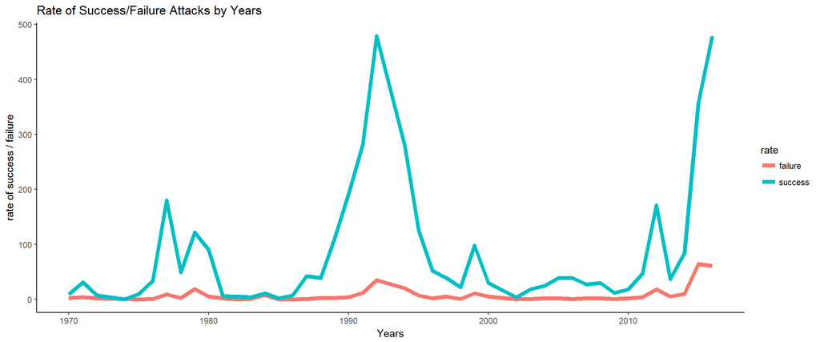

```r
gtd.turkey %>%
  mutate(total = 1) %>% # total attacks that year (creates a new variable)
  count(year, wt=total-success) %>% # failed attempt
  cbind("failure") -> failure
  colnames(failure)[3] <- "rate"

gtd.turkey %>%
  count(year, wt = success) %>%
  cbind("success")-> success
colnames(success)[3] <- "rate"

rbind(failure,success) %>%
  ggplot(aes(year,n)) +
  geom_line(aes(group=rate, colour=rate),size = 2)+
  ggtitle("Rate of Success/Failure Attacks by Years") +
  labs(x = "Years", y = "rate of success / failure")
```

It is seen that the ratio which is at a certain level in each period; shows an increasing tendency in recent years.

#### Frequency of Attacks by Attacktype

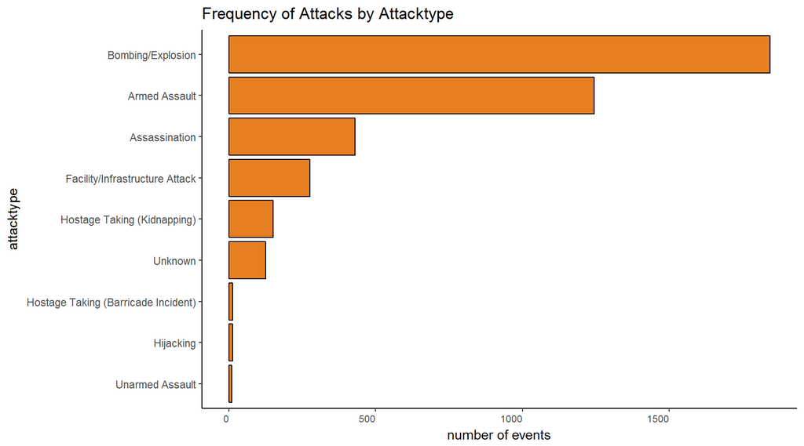

```r
gtd.turkey %>%
    group_by(attacktype1)%>%
    count() %>%
    arrange(desc(n)) %>%
      ggplot(aes(x=reorder(attacktype1,n),y=n)) +
      geom_bar(stat = "identity",fill= ('#e67e22'), color='black') +
      theme(axis.text.x = element_text(size=8,vjust=1, hjust=1)) +
      labs(x= 'attacktype', y= 'number of events') +
      ggtitle('Frequency of Attacks by Attacktype') +
      coord_flip()
```

Above figure shows the number of terrorist attacks in the Turkey from 1970 to 2016, by attack type. The most common form of terrorist attack in the Turkey was a **Bombing/Explosion** type attack.

#### Frequency of Attacks by Target type

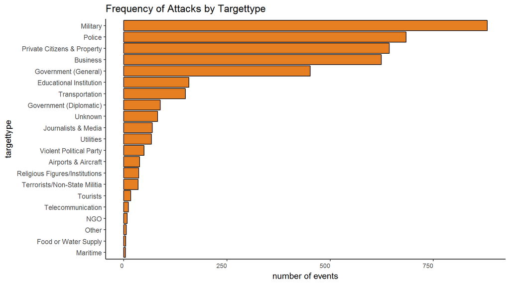

```r
gtd.turkey %>%
    group_by(targtype1)%>%
    count() %>%
    arrange(desc(n)) %>%
      ggplot(aes(x=reorder(targtype1,n),y=n)) +
      geom_bar(stat = "identity",fill= ('#e67e22'), color='black') +
      theme(axis.text.x = element_text(size=8,vjust=1, hjust=1)) +
      labs(x= 'targettype', y= 'number of events') +
      ggtitle('Frequency of Attacks by Targettype') +
      coord_flip()
```

#### Frequency of Attacks by Weapon type

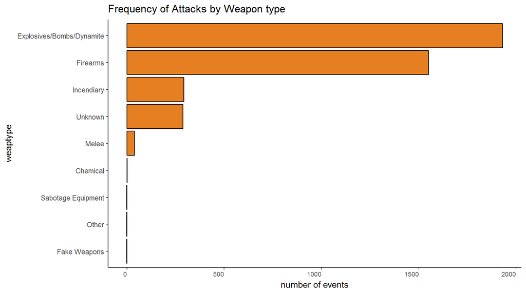

```r
gtd.turkey %>%
    group_by(weaptype1)%>%
    count() %>%
    arrange(desc(n)) %>%
      ggplot(aes(x=reorder(weaptype1,n),y=n)) +
      geom_bar(stat = "identity",fill= ('#e67e22'), color='black') +
      theme(axis.text.x = element_text(size=8,vjust=1, hjust=1)) +
      labs(x= 'weaptype', y= 'number of events') +
      ggtitle('Frequency of Attacks by Weapon type') +
      coord_flip()
```

#### Frequency of Group Name

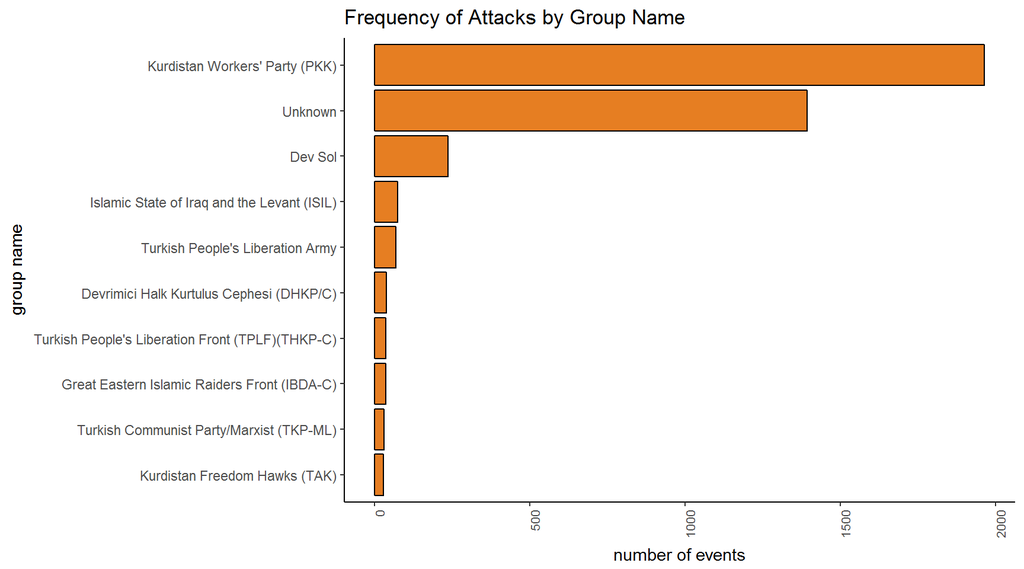

```r
gtd.turkey %>%
    group_by(gname)%>% # group by gname
    count() %>% # count the number of times a gname appear
    arrange(desc(n)) %>% # subset by rows based on condition
    head(n=10) %>%
      ggplot(aes(x=reorder(gname,n),y=n))+
      geom_bar(stat = "identity",fill= ('#e67e22'), color='black') +
      theme(axis.text.x = element_text(angle=90,size=8,vjust=1, hjust=1)) +
      labs(x= 'group name', y= 'number of events') +
      ggtitle('Frequency of Attacks by Group Name') +
      coord_flip()
```

#### Change in Number of Attacks by Terrorist Groups in last two years

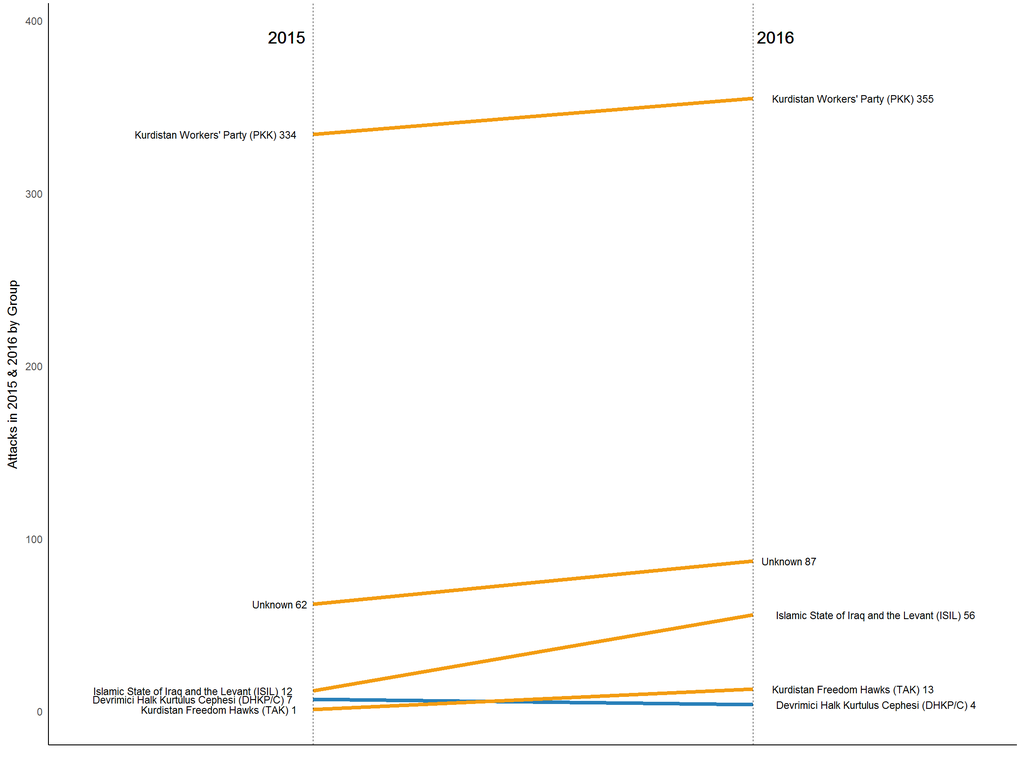

```r
library(reshape)
target <- c("2015", "2016")
year_change<- gtd.turkey%>%
  filter(year %in% target) %>%
  group_by(gname, year)%>%
  summarise(number_of_attacks=n())
year_change <- year_change[-c(1, 4, 5, 12,13,14,15,16,17), ]
df<-cast(year_change, gname ~ year)

# prep data
colnames(year_change) <- c("gname", "2015", "2016")
left_label <- paste(df$continent, (df$gname),round(df$`2015`))
right_label <- paste(df$continent, (df$gname),round(df$`2016`))
df$class <- ifelse((df$`2016` - df$`2015`) < 0, "blue", "orange")

# Plot
plot <- ggplot(df) + geom_segment(aes(x=1, xend=2, y=`2015`, yend=`2016`, col=class), size=1.5, show.legend=F) +
  geom_vline(xintercept=1, linetype="dashed", size=.1) +
  geom_vline(xintercept=2, linetype="dashed", size=.1) +
  scale_color_manual(labels = c("Up", "Down"),
                     values = c("orange"="#f39c12", "blue"="#2980b9")) +  # color of lines
  labs(x="", y="Attacks in 2015 & 2016 by Group") +  # Axis labels
  xlim(.5, 2.5) + ylim(0,(1.1*(max(df$`2015`, df$`2016`))))  # X and Y axis limits

# Add texts
plot <- plot + geom_text(label=left_label, y=df$`2015`, x=rep(1, NROW(df)), hjust=1.1, size=3)
plot <- plot + geom_text(label=right_label, y=df$`2016`, x=rep(2, NROW(df)), hjust=-0.1, size=3)
plot <- plot + geom_text(label="2015", x=1, y=1.1*(max(df$`2015`, df$`2016`)), hjust=1.2, size=5)  # title
plot <- plot + geom_text(label="2016", x=2, y=1.1*(max(df$`2015`, df$`2016`)), hjust=-0.1, size=5)  # title

# Minify theme
plot + theme(panel.background = element_blank(),
          panel.grid = element_blank(),
          axis.ticks = element_blank(),
          axis.text.x = element_blank(),
          panel.border = element_blank(),
          plot.margin = unit(c(0.1,0.2,0.1,0.2), "cm"))
```

This graphic shows the number of attacks of the terrorist groups which have attacked in last two years (2015 -2016) comparing the previous year. When we ignore the unknown attacks, it seems that 3 of 4 groups have increased the total number attacks.

#### Attacks vs Casualities

```r
# Summary by year respect to event and casualties (Pivot)
gtd.turkey.year= group_by(gtd.turkey, year) %>%
  summarise(numberOfEvents = length(eventid), numberOfCasualties = sum(nkill, na.rm = TRUE))
```

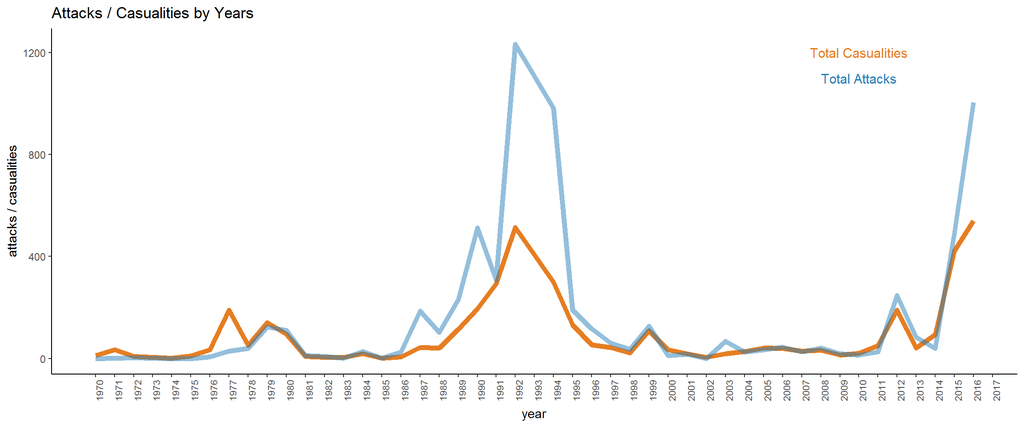

```r
ggplot(gtd.turkey.year, aes(x = year)) +
  geom_line(aes(y = numberOfEvents), size = 2,colour = '#e67e22') +
  geom_line(aes(y = numberOfCasualties), size = 2, ,colour = ('#2980b9'), alpha=0.5) +
  scale_x_continuous(breaks=seq(1970,2017,1)) +
  annotate("text", x = c(2010,2010), y = c(1200,1100),
           label = c("Total Casualities", "Total Attacks"), colour = c(('#e67e22'), ('#2980b9')), size = 4)  +
  ggtitle("Attacks / Casualities by Years") +
  theme(axis.text.x = element_text(angle=90, size=8)) +
  labs(x = "year", y = "attacks / casualities")
```

#### Killed vs Wounded Rate

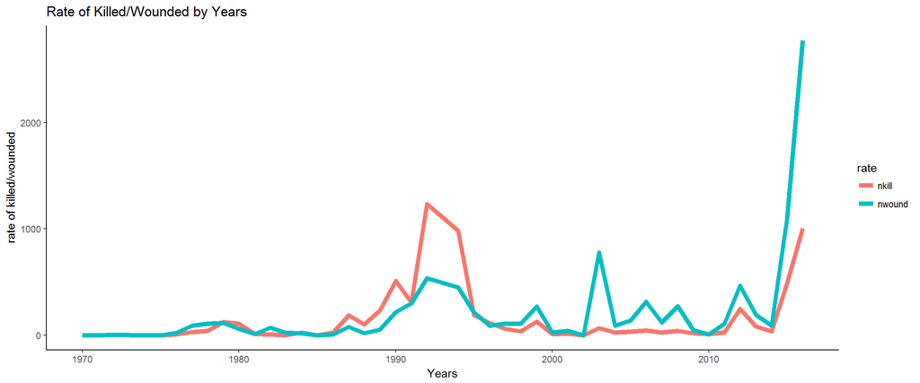

```r
gtd.turkey %>%
  mutate(total = 1) %>% # total attacks that year (creates a new variable)
  count(year, wt=nkill) %>% # failed attempt
  cbind("nkill") ->killed
  colnames(killed)[3] <- "rate"

gtd.turkey %>%
  count(year, wt = nwound) %>%
  cbind("nwound")-> wounded
colnames(wounded)[3] <- "rate"

rbind(killed,wounded) %>%
  ggplot(aes(year,n)) +
  geom_line(aes(group=rate, colour=rate),size = 2)+
  ggtitle("Rate of Killed/Wounded by Years") +
  labs(x = "Years", y = "rate of killed/wounded")
```

This graphic summarizes rate of death and wounded by years. It is obviously seen in 90’s that death rate is much more than wounded rate for each attack. However, in recent years this situation has reversed and wounded rate by virtue of the attacks has dramatically started to increase. This case can be explained in two possibilities. One of them is, increasing the total attacks which may cause more people, the other is lower incidence of these attacks.

#### gname vs nkill

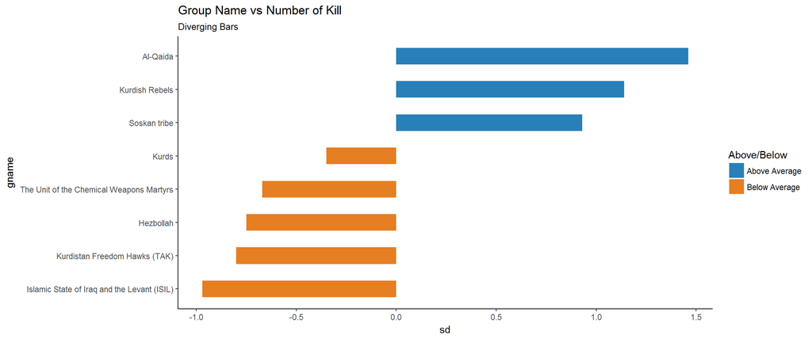

```r
gtd.turkey$nkill[is.na(gtd.turkey$nkill)] <- 0
gnamevnkill<-gtd.turkey%>%
  group_by(gname)%>%
  summarise(avgkillperattack= mean(nkill)) %>%
  filter(avgkillperattack > 5)

# Data Prep
gnamevnkill$sd <- round((gnamevnkill$avgkillperattack - mean(gnamevnkill$avgkillperattack))/sd(gnamevnkill$avgkillperattack), 2)  # compute normalized mpg
gnamevnkill$mpg_type <- ifelse(gnamevnkill$sd < 0, "below", "above")  # above / below avg flag
gnamevnkill <- gnamevnkill[order(gnamevnkill$sd), ]  # sort
gnamevnkill$gname <- factor(gnamevnkill$gname, levels = gnamevnkill$gname)  # convert to factor to retain sorted order in plot.

# Diverging Barcharts
ggplot(gnamevnkill, aes(x=gname, y=sd, label=sd)) +
  geom_bar(stat='identity', aes(fill=mpg_type), width=.5)  +
  scale_fill_manual(name="Above/Below",labels = c("Above Average", "Below Average"),
                    values = c("above"="#2980b9", "below"="#e67e22")) +
  labs(subtitle="Diverging Bars",
       title= "Group Name vs Number of Kill") +
  coord_flip()
```

This graph compares each group which have caused more than 5 deaths in average due to their attacks with the average of the means the total group’s. It is used standard normal distribution formula to see which terrorist group’s death cause are in place above and below in terms of population mean.

#### Yearly terrorist attacks by Attack type

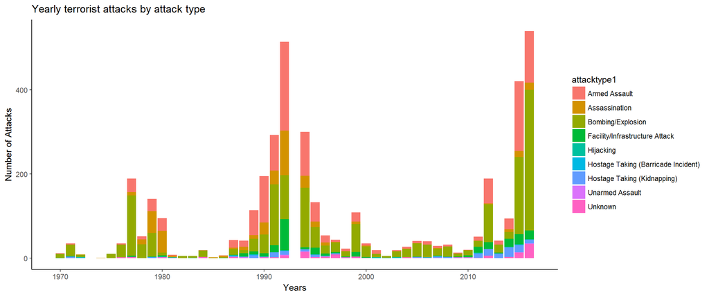

```r
  ggplot(data=gtd.turkey, aes(x=year,fill=attacktype1)) +
  geom_bar() + ggtitle("Yearly terrorist attacks by attack type")+
    labs(x = "Years", y = "Number of Attacks")
```

This graphics shows, which attack type is used by terrorist groups to organize an attack by years. It is seen that the most popular attack types are armed assault and bombing almost each year.

#### Terrorist attacks in Turkey between 1970-2016 by attack type

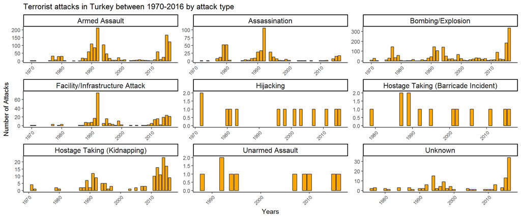

```r
ggplot(gtd.turkey, aes(x = year))+ labs(title ="Terrorist attacks in Turkey between 1970-2016 by attack type", x = "Years", y = "Number of Attacks", size = 15) +
  geom_bar(colour = "grey19", fill = "orange") +
  facet_wrap(~attacktype1,scales = "free", ncol = 3) +
  theme(axis.text.x = element_text(angle=45,hjust = 1, size = 8)) +
  theme(strip.text = element_text(size = 12))
```

```r
##Inspiration:"https://www.kaggle.com/pranav84/visualizing-terrorist-attacks-on-india"
```

#### Causalities in Turkey between 1970-2016 by attack type

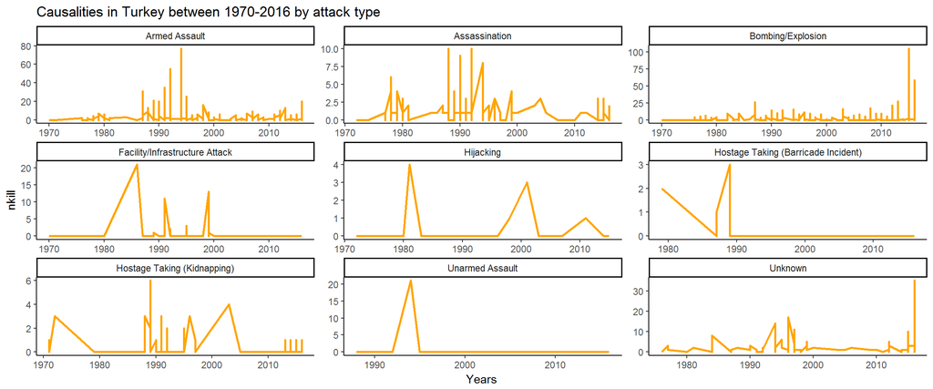

```r
ggplot(gtd.turkey, aes(x = year,y=nkill))+
  labs(title ="Terrorist attacks in Turkey by attack type", x = "Years", y = "Number of Attacks", size = 15) +
  geom_line(colour = "orange",size = 1) +
  facet_wrap(~attacktype1,scales = "free", ncol = 3) +
  ggtitle("Causalities in Turkey between 1970-2016 by attack type")+
  labs(x = "Years", y = "nkill")
```

#### gname vs targtype1

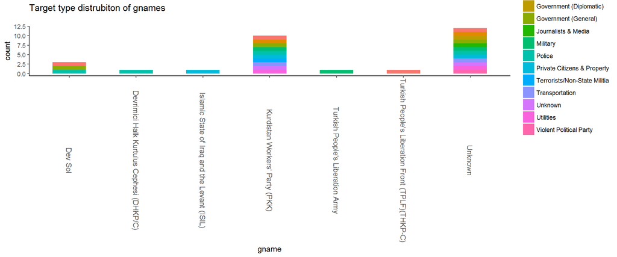

```r
gnamevstargtype1<-gtd.turkey%>%
  group_by(gname, targtype1)%>%
  summarise(numberOfEvents=n())%>%
  filter(numberOfEvents>15)

# Histogram on a Categorical variable
g <- ggplot(gnamevstargtype1, aes(gname))
g + geom_bar(aes(fill=targtype1), width = 0.5) +
  theme(axis.text.x = element_text(angle=-90, vjust=0.5,size=10)) +
  labs(title="Target type distrubiton of gnames",
       subtitle="")
```

#### Yearly terrorist attacks by Weapon type

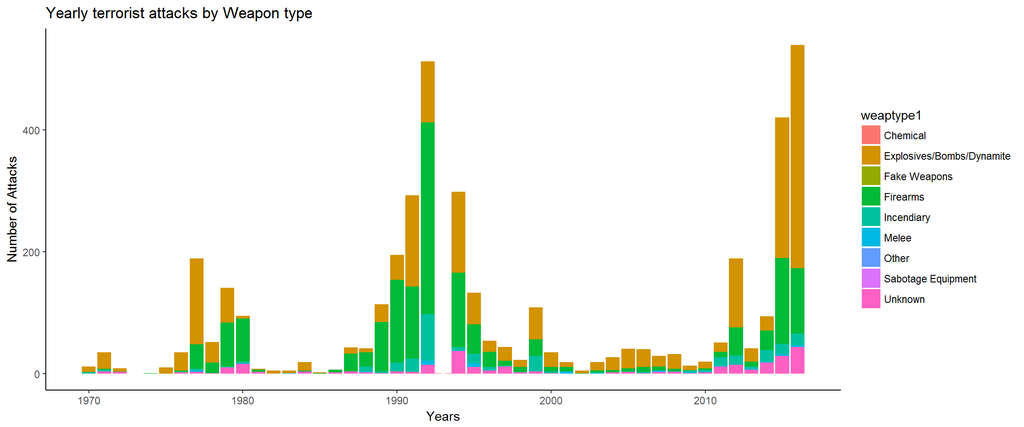

```r
  ggplot(data=gtd.turkey, aes(x=year,fill=weaptype1)) +
    geom_bar() + ggtitle("Yearly terrorist attacks by Weapon type")+
    labs(x = "Years", y = "Number of Attacks")
```

### Wordcloud Analysis

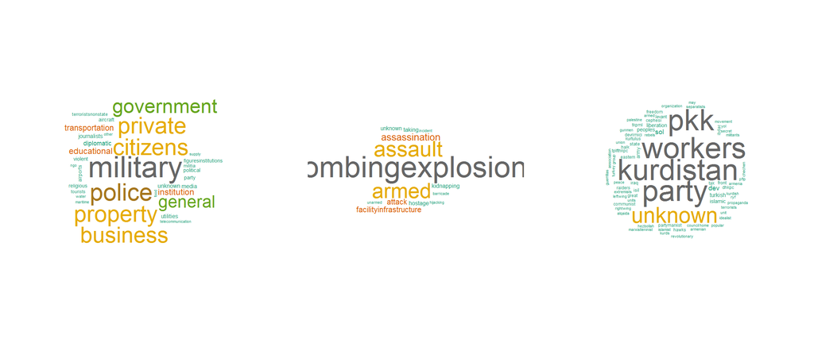

```r
# Install wordcloud if not already installed
if (!("wordcloud" %in% installed.packages())) {
    install.packages("wordcloud", repos = "https://cran.r-project.org")}

# Load wordcloud package
library(wordcloud)
par(mfrow = c(1,3))
wordcloud(gtd.turkey$targtype1,max.words = 100,random.order = FALSE,colors=brewer.pal(8, "Dark2"))
wordcloud(gtd.turkey$attacktype1,max.words = 100,random.order = FALSE,colors=brewer.pal(8, "Dark2"))
wordcloud(gtd.turkey$gname,max.words = 100,random.order = FALSE,colors=brewer.pal(8, "Dark2"))
```

```r
##Inspiration:"https://www.kaggle.com/bharathsivaraman/an-untold-story-of-terrorism-in-india/notebook"
```

### Analysis on Map

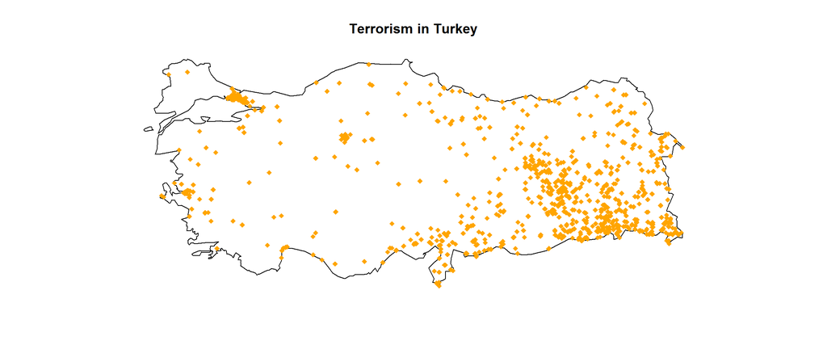

```r
library(sp)           # spatial data classes and functions
library(maptools)
library(RColorBrewer)
library(maps)         # powerful and flexible mapping package
library(mapdata)

lon_lat <- data.frame(lon=gtd.turkey$longitude, lat=gtd.turkey$latitude)
map("world2Hires", "Turkey")
points(lon_lat$lon, lon_lat$lat, col="orange", pch=18)
title("Terrorism in Turkey")
```

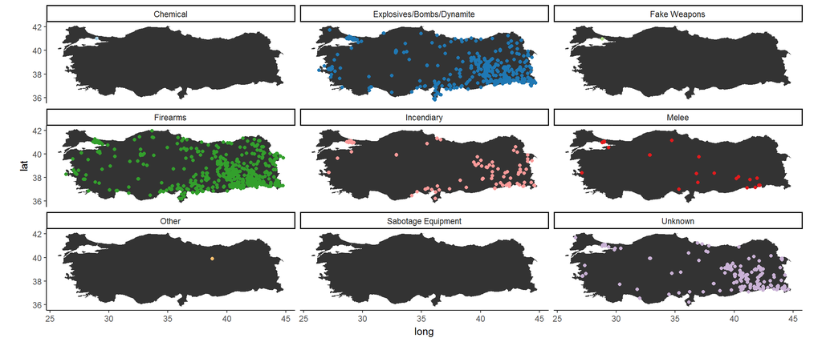

```r
#What are the most used weapons?
weapons<-unique(gtd.turkey$weaptype1)
library(ggmap)
map_tr<-map_data("world2Hires","Turkey")
map_by_weapon<- ggplot() + geom_polygon(data = map_tr, aes(x=long, y = lat, group = group)) +
  coord_fixed(1)
map_by_weapon<-map_by_weapon+geom_point(data=gtd.turkey,aes(x=longitude,y=latitude,color=as.factor(weaptype1)))
map_by_weapon<-map_by_weapon+scale_color_brewer(palette="Paired")+facet_wrap(~weaptype1,ncol=3)+guides(color=F)
map_by_weapon
```

```r
##Inspiration:"https://www.kaggle.com/aiswaryaramachandran/terror-attacks-against-india-since-2000"
```

From the visualisation above, we can observe that Firearms and Bombing/Explosion is the most common type of attack and highly prevalent in especially southeast part of Turkey.

### Interactive Data Map with Shiny module

[Interactive Data Map](https://sevgilit.shinyapps.io/GTD_Shiny/)

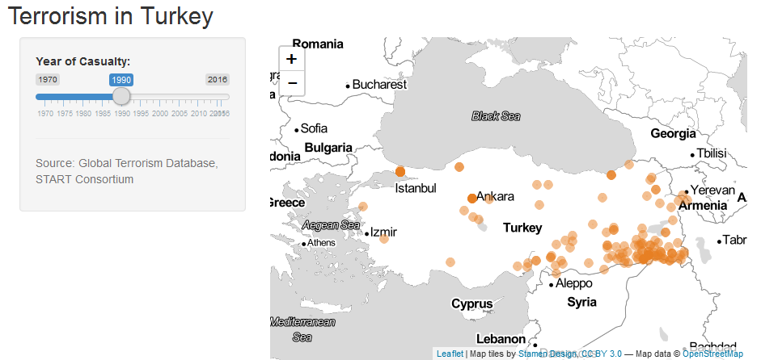

## References

*Dataset source*

1. [Global Terrorism Database](https://www.kaggle.com/START-UMD/gtd)
2. https://www.kaggle.com/dhrubajitdas/global-terrorism-full-analysis/data
3. http://start.umd.edu/gtd/downloads/Codebook.pdf

*Visualization and ggplot*

1. http://r-statistics.co/ggplot2-Tutorial-With-R.html
2. http://ggplot2.tidyverse.org/reference/
3. https://www.computerworld.com/article/2935394/business-intelligence/my-ggplot2-cheat-sheet-search-by-task.html
4. https://plot.ly/r/pie-charts/
5. https://www.statmethods.net/graphs/pie.html
6. http://rstudio-pubs-static.s3.amazonaws.com/15358_25737b089f0042e086e68b1609e4f20b.html
7. https://stackoverflow.com/questions/19926349/side-by-side-pie-charts-of-2-matrices-r
8. http://bl.ocks.org/patilv/raw/7360425/
9. https://www.harding.edu/fmccown/r/
10. https://uc-r.github.io/lollipop
11. https://www.kaggle.com/iklotho/terror-attacks-in-turkey/notebook

*Shiny*

1. https://rstudio.github.io/leaflet/shiny.html
2. http://shiny.rstudio.com/tutorial/

*Other*

1. http://zevross.com/blog/2014/08/04/beautiful-plotting-in-r-a-ggplot2-cheatsheet-3/
2. http://www.css.cornell.edu/faculty/dgr2/teach/R/R_corregr.pdf
3. https://www.programiz.com/r-programming
4. http://lightonphiri.org/blog/ggplot2-multiple-plots-in-one-graph-using-gridextra
5. http://www.cookbook-r.com/Graphs/Multiple_graphs_on_one_page_(ggplot2)/